# Getting Started with Jupyter Notebooks

The goal of this Jupyter notebook is to introduce you to working with the Jupyter Notebook software.

## Learning Objectives

After this section, you should

- Have an **overview of the tools**.
- Have **properly installed tools**.
- Know how to **start the tools**.
- Know how to **locate and open existing notebooks**, and **create new notebooks**.
- Know basic commands to **edit and run a notebook** in the Editor.
- Know about the **formatting of text cells**.
- Know how to **save and rename** notebooks.
- Know how to **interrupt the execution** of a notebook.
- Know about **keyboard shortcuts** for common commands.
- Know **guidelines for notebooks** delivered to others.
- Know how to find **help**.

## 1. Tools - Python 3 & Jupyter Notebook

The two main tools are:

- **Python** (version 3), the programming language, and
- **Jupyter Notebook**, software to work with computational documents.

A **computational document** is a document that contains a mixture of *textual* and *computational* elements. In our case, the computations are expressed in the Python 3 programming language.

When working with Jupyter Notebook, the computational documents are called **Jupyter notebooks**, or simply *notebooks*. Such notebooks are stored in files with the **file name extension `.ipynb`**.

A notebook consists of a sequence of **cells**. Cells come in three types:

- **MarkDown cells**, containing *formatted text*, including formulas typeset with $\LaTeX$, e.g. $a x^2 + b x + c = 0$;
- **Code cells**, containing (Python) program fragments, e.g. `print('Hello')`, and;
- **Raw cells** that are passed on unchanged to other tools (we will not need such raw cells).

These programming lessons have been written as Jupyter notebooks, and they contain computational elements.

Here is an example of a simple code cell:

```python
print('Hello, 6 * 7 =', 6 * 7)
```

```
Hello, 6 * 7 = 42
```

The result of the computation is shown in the output panel below the code cell.

When doing these programming lessons, it is best to play along in a notebook, and try out all the examples yourself.

But before you can do so, there are four more hurdles to take:

1. **install the tools**,
2. **start the Jupyter Notebook software**,
3. **open a notebook**, and
4. **edit and run a notebook**.

## 2. Installing the Tools

All laptops provided to new first-year students at **TU/e** (Eindhoven University of Technology) already contain a complete installation of the tools. For other students, the `install-tools.html` document explains how to install the tools.

Even if you already have the tools installed, you should

- **verify your tool installation** (described at the bottom of this document), and
- **understand the issues with updating and uninstalling** (described in `install-tools.html`).

## 3. Starting Jupyter Notebook

To start Jupyter Notebook in a simple way:

1. Launch the **Anaconda-Navigator** application.
2. From there, launch **Jupyter Notebook**.

[figure not shown]

## 4. Opening a Notebook from the Dashboard

When you launch Jupyter Notebook, it will

- start the Jupyter Notebook *server* in the background (forget about this for now) and
- open a window in your default *web browser*.

That window is the Graphical User Interface (GUI) for the **Jupyter Notebook Dashboard**, or *Dashboard* for short (see image on the right).

You use the Dashboard to browse your file system, and locate notebooks and other files.

- Click on a folder to descend into it, and show its contents.
- Click on a file to open it in the editor.

Note that you can only access files on the disk where Jupyter was started. Make sure that your notebooks are on that disk. Consult the **Tool FAQ** for alternatives.

[figure not shown]

You can also select files and folders via the checkboxes, and then choose

- **Duplicate** (files only),
- **Rename** (files and folders), or
- **Delete** (files only).

[figure not shown]

On the right-hand side, you can choose **New** to create a new

- notebook,
- text file,
- folder, or
- terminal window.

To proceed, **create a new notebook**, and read on for further instructions.

## 5. Editing a Notebook in the Editor

[figure not shown]

When you open a notebook from the Dashboard, it will open a new browser window/tab with the GUI for the **Jupyter Notebook Editor**, or *Editor* for short.

At the top of that window, you see the **Notebook Menubar** and **Notebook Toolbar** (see image above). Hovering the mouse pointer over a toolbar button evokes a tooltip.

Select **Help > User Interface Tour** to get explanations for the various GUI elements. Do that now.

### Command Mode and Edit Mode

When you **click on a cell**, *outside* the light gray area, you select it in **Command Mode**: a *blue bar* appears. Here is an unexecuted empty code cell in Command Mode:

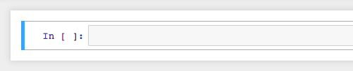

You can also use the keyboard to switch between Command Mode and Edit Mode:

- **Enter** (the Enter key) switches from Command Mode to Edit Mode.
- **Esc** (the Escape key) switches from Edit Mode to Command Mode.

When you **click in the cell**, *inside* the light gray area, you select it in **Edit Mode**: a *green bar* appears. You can now type Python code into that cell. Type the following code into your code cell:

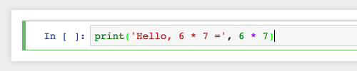

Next follows the actual code cell.

```python
print('Hello, 6 * 7 =', 6 * 7 )
```

```
Hello, 6 * 7 = 42
```

## 6. Running a Notebook in the Editor

You can **execute**, also known as **run**, the selected code cell in several ways:

- Select the menu item **Cell > Run Cells** in the Menubar.
- Click the '**run cell**' button in the Toolbar.
- Type **Control-Enter** on the keyboard.

[figure not shown]

The output of the executed code cell appears below it. To the left of the code cell, the **execution count** appears between brackets: **`In [1]`**.

These execution counts tell you in what order cells were executed. When a code cell has not yet been executed, it is labeled **`In [ ]`**.

To **run all cells** in a notebook, starting at the very top, select menu item **Cell > Run All**.

## 7. MarkDown Cells and Formatted Text

The '**add cell below**' button in the Toolbar adds a new code cell *below* the selected cell.

In the popup menu in the Toolbar, you can see the type of the selected cell:

[figure not shown]

.

Change the type through that menu to

[figure not shown]

.

The label **`In [ ]:`** disappears. Type the following (or your own) *MarkDown*-formatted text in your MarkDown cell:

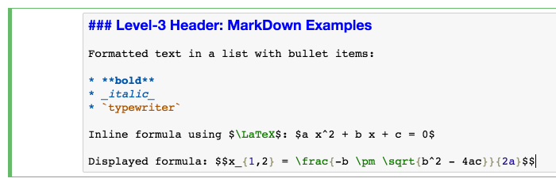

What you see is the **source view**, with syntax highlighting. It is not yet *rendered*.

To render the formatting, **run the cell** just like a code cell. This is the **rendered view** of that same MarkDown cell:

[figure not shown]

To switch to the source view and Editing Mode again, select the MarkDown cell, and

- type **Enter**, or
- **double-click** inside the rendered area.

## 8. Saving and Renaming a Notebook

You can **save** a notebook in any of the following ways.

- Select the menu item **File > Save and Checkpoint** in the Menubar.
- Click the **Save and Checkpoint** button in the Toolbar (on the left).
- Type **`s`** (the letter "`s`") on the keyboard.
- Type Ctrl-S (Windows/Linux) or Cmd-S (MacOS).

And this is how you can **rename** a notebook.

- Select the menu item **File > Rename...** in the Menubar.
- Click on the notebook's file name at the top of the page, next to the Jupyter logo.

*Warning*: Whenever you have a notebook open in the Jupyter Notebook Editor, do **NOT** modify it *outside* that editor session. In particular, do not edit it in another editor session, and do not rename it in your operating system. If you want to do so, close it first: **File > Close and Halt**.

[figure not shown]

## 9. Interrupting Execution

When a code cell is being executed, its label is changed to **`In [*]`**, and the *kernel status indicator* in the top right-hand corner changes from an **open circle** into a **filled circle**.

If you find that the execution of a code cell takes too long, then you can interrupt execution as follows.

[figure not shown]

- Select the menu item **Kernel > Interrupt** in the Menubar.
- Click the **interrupt kernel** button in the toolbar.
- Type `ii` (two times the letter "`i`") on the keyboard.

## 10. Keyboard Shortcuts

Many commands have keyboard shortcuts. To get an overview of keyboard shortcuts on your platform, select **Help > Keyboard Shortcuts**.

These are the most useful keyboard shortcuts when you work with notebooks more often:

- In **Command Mode** (blue & gray cell border):
  - **Enter**: switch to Edit mode
  - Help: **h**(elp)
  - New cell: **a**(bove), **b**(elow)
  - Change cell type: **m**(arkdown), **y** (code)
  - Cut, copy, paste below/above (in same notebook), delete: **x**, **c**, **v** / **V**, **dd**
  - Copy, paste multiple cells between notebooks: **Ctrl/Cmd-C**, **Ctrl/Cmd-V**
  - Find/replace: **f**(ind/replace)
  - Toggle line numbers: **l**(ine numbers)
- In **Edit Mode** (green cell border):
  - **Esc**: switch to Command mode
  - **Tab**: code completion
  - **Shift-Tab**, **Shift-Tab-Tab**: get (more) documentation
  - **Ctrl-Enter**; **Shift-Enter**; **Alt-Enter**: format/run cell; ... and select next; ... and create a new cell below

In the beginning, it can also be useful to consult the **command palette** in the Toolbar (on the right).

## 11. Delivering and Presenting Notebooks to Others

When you work in a notebook just for yourself, you are free to make a mess of it.

Whenever you need to deliver or present a notebook to someone else (e.g. to get feedback), follow these guidelines:

1. Include your **full name**, **ID number**, and the **date** at the top.
2. Structure your notebook with **headers**.
3. Keep cells **short**, each cell focusing on one task.
4. Include **explanatory text** using MarkDown for all program fragments.
5. Make sure that the notebook **runs without errors** when executed **in linear order**, by running **Kernel > Restart & Run All**.

[figure not shown]

## 12. Help, Documentation, More Information

The **Help** menu in the Menubar provides access to documentation about various things, including

- Jupyter Notebook
- Python and IPython (Interactive Python)
- Common Python Libraries

Be prepared to consult such documentation (and at times you may even have to search the web for answers).

These programming lessons are accompanied by some additional support notebooks in the `extra` folder:

- **`FAQ.ipynb`**: frequently asked/answered questions.
- **`Summary-*.ipynb`**: a summary of the methods introduced in the programming exercises for a particular topic.

During lab sessions, you can get personal assistance.

## 13. Summary

After this section, you should

[figure not shown]

[figure not shown]

## Action Required: Verify Your Tool Installation

Before continuing with the course, you should verify that you have the right tools.

1. Copy the **`verify-tools-template.ipynb`** notebook, and rename it to **`verify-tools-yourIDnr.ipynb`**.
2. Launch the **Anaconda-Navigator**.
3. In it, launch **Jupyter**.
4. Navigate to the **`verify-tools-yourIDnr.ipynb`** notebook, and open it.
5. Follow the instructions in the notebook.
6. Save the executed notebook: **File > Save and Checkpoint**.
7. Submit your executed **`verify-tools-yourIDnr.ipynb`** on Canvas.
8. Check that you get 10 points.

# (End of Notebook)

© 2017-2023 - **TU/e** - Eindhoven University of Technology